title: “SVM”

author: “Mikołaj Malec”

date: “4/28/2020”

output: html_document

## Data *apartments* from DALEX

```r
set.seed(123)

df_apartments <- DALEX::apartments

#split

n_train <- 1000

n_split <- n_train * 9/10

ind_sam <- sample( 1:dim( DALEX::apartments)[1], n_train)



df_train <- df_apartments[ind_sam[1:n_split],]

df_test <- df_apartments[ind_sam[(n_split+1):n_train],]

## explore data

# first rows

head( df_apartments)
```

```
##   m2.price construction.year surface floor no.rooms    district
## 1     5897              1953      25     3        1 Srodmiescie
## 2     1818              1992     143     9        5     Bielany
## 3     3643              1937      56     1        2       Praga
## 4     3517              1995      93     7        3      Ochota
## 5     3013              1992     144     6        5     Mokotow
## 6     5795              1926      61     6        2 Srodmiescie
```

```r
# summary of columns

summary( df_apartments)
```

```
##     m2.price    construction.year    surface           floor
##  Min.   :1607   Min.   :1920      Min.   : 20.00   Min.   : 1.000
##  1st Qu.:2857   1st Qu.:1943      1st Qu.: 53.00   1st Qu.: 3.000
##  Median :3386   Median :1965      Median : 85.50   Median : 6.000
##  Mean   :3487   Mean   :1965      Mean   : 85.59   Mean   : 5.623
##  3rd Qu.:4018   3rd Qu.:1988      3rd Qu.:118.00   3rd Qu.: 8.000
##  Max.   :6595   Max.   :2010      Max.   :150.00   Max.   :10.000
##
##     no.rooms           district
##  Min.   :1.00   Mokotow    :107
##  1st Qu.:2.00   Wola       :106
##  Median :3.00   Ursus      :105
##  Mean   :3.36   Ursynow    :103
##  3rd Qu.:4.00   Srodmiescie:100
##  Max.   :6.00   Bemowo     : 98
##                 (Other)    :381
```

```r
# dimensions of data frame and types of columns

str( df_apartments)
```

```
## 'data.frame':    1000 obs. of  6 variables:
##  $ m2.price         : num  5897 1818 3643 3517 3013 ...
##  $ construction.year: num  1953 1992 1937 1995 1992 ...
##  $ surface          : num  25 143 56 93 144 61 127 105 145 112 ...
##  $ floor            : int  3 9 1 7 6 6 8 8 6 9 ...
##  $ no.rooms         : num  1 5 2 3 5 2 5 4 6 4 ...
##  $ district         : Factor w/ 10 levels "Bemowo","Bielany",..: 6 2 5 4 3 6 3 7 6 6 ...
```

```r
# there is no missing data

sum( is.na( df_apartments))
```

```
## [1] 0
```

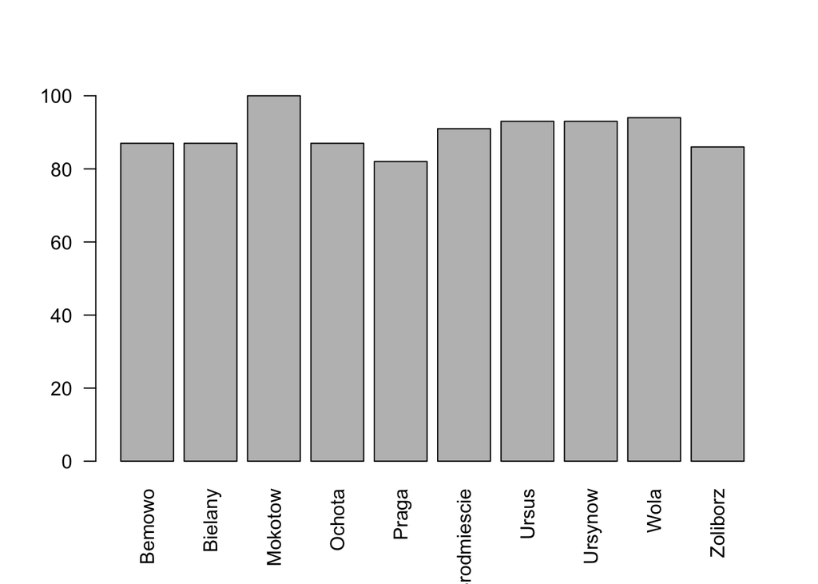

```r
# distribution of target

plot( df_train[6], las=2)
```

Because target is balanced, that means that accuracy is the best metric for this example.

### Random search of hiperparameters for SVM

Color represents a degree parameter.

Click plot for interactivity.

[interactive chart not shown]

Best accuracy = 0.34 is for C = 10.2154937, gamma = 0.2729199 and degree = 3

Data has been randomly generated. Many districts aren“t diverse to be sliced. Exeption is Srodmiescie which is very distinguishable for others. It”s no worry that accuracy is so small. Confusion matrix for the best is:

|  | Bemowo | Bielany | Mokotow | Ochota | Praga | Srodmiescie | Ursus | Ursynow | Wola | Zoliborz |
| --- | --- | --- | --- | --- | --- | --- | --- | --- | --- | --- |
| Bemowo | 2 | 2 | 0 | 0 | 2 | 0 | 2 | 1 | 2 | 0 |
| Bielany | 1 | 2 | 0 | 0 | 0 | 0 | 0 | 1 | 1 | 0 |
| Mokotow | 0 | 0 | 3 | 2 | 0 | 0 | 0 | 0 | 0 | 5 |
| Ochota | 0 | 0 | 0 | 2 | 0 | 0 | 0 | 0 | 0 | 2 |
| Praga | 1 | 1 | 0 | 0 | 2 | 0 | 2 | 1 | 1 | 0 |
| Srodmiescie | 0 | 0 | 0 | 0 | 0 | 9 | 0 | 0 | 0 | 0 |
| Ursus | 2 | 1 | 0 | 0 | 2 | 0 | 6 | 5 | 1 | 0 |
| Ursynow | 4 | 1 | 0 | 0 | 1 | 0 | 1 | 1 | 4 | 0 |
| Wola | 1 | 2 | 0 | 0 | 3 | 0 | 1 | 1 | 3 | 0 |
| Zoliborz | 0 | 0 | 4 | 5 | 0 | 0 | 0 | 0 | 0 | 4 |

## Data *weather* from nycflights13

```r
#delete columns with many missing

DataExplorer::profile_missing( nycflights13::weather)
```

```
## # A tibble: 15 x 3
##    feature    num_missing pct_missing
##    <fct>            <int>       <dbl>
##  1 origin               0   0
##  2 year                 0   0
##  3 month                0   0
##  4 day                  0   0
##  5 hour                 0   0
##  6 temp                 1   0.0000383
##  7 dewp                 1   0.0000383
##  8 humid                1   0.0000383
##  9 wind_dir           460   0.0176
## 10 wind_speed           4   0.000153
## 11 wind_gust        20778   0.796
## 12 precip               0   0
## 13 pressure          2729   0.104
## 14 visib                0   0
## 15 time_hour            0   0
```

```r
df_weather <- nycflights13::weather[,c(-9,-11,-13)]

#delete rows with some missing obesvations

df_weather <- df_weather[ complete.cases(df_weather),]



#no need for posic column and date columns

df_weather$time_hour <- NULL

df_weather$year <- NULL

df_weather$month <- NULL

df_weather$day <- NULL

df_weather$hour <- NULL



df_weather$origin <- as.factor( df_weather$origin)



#split

n_train <- 10000

n_split <- n_train * 9/10

ind_sam <- sample( 1:dim(nycflights13::weather)[1], n_train)



df_train <- df_weather[ind_sam[1:n_split],]

df_test <- df_weather[ind_sam[(n_split+1):n_train],]



## explore data

# first rows

head( df_weather)
```

```
## # A tibble: 6 x 7
##   origin  temp  dewp humid wind_speed precip visib
##   <fct>  <dbl> <dbl> <dbl>      <dbl>  <dbl> <dbl>
## 1 EWR     39.0  26.1  59.4      10.4       0    10
## 2 EWR     39.0  27.0  61.6       8.06      0    10
## 3 EWR     39.0  28.0  64.4      11.5       0    10
## 4 EWR     39.9  28.0  62.2      12.7       0    10
## 5 EWR     39.0  28.0  64.4      12.7       0    10
## 6 EWR     37.9  28.0  67.2      11.5       0    10
```

```r
# summary of columns

summary( df_weather)
```

```
##  origin          temp             dewp           humid
##  EWR:8701   Min.   : 10.94   Min.   :-9.94   Min.   : 12.74
##  JFK:8703   1st Qu.: 39.92   1st Qu.:26.06   1st Qu.: 47.05
##  LGA:8706   Median : 55.40   Median :42.08   Median : 61.79
##             Mean   : 55.26   Mean   :41.44   Mean   : 62.53
##             3rd Qu.: 69.98   3rd Qu.:57.92   3rd Qu.: 78.79
##             Max.   :100.04   Max.   :78.08   Max.   :100.00
##    wind_speed           precip             visib
##  Min.   :   0.000   Min.   :0.000000   Min.   : 0.000
##  1st Qu.:   6.905   1st Qu.:0.000000   1st Qu.:10.000
##  Median :  10.357   Median :0.000000   Median :10.000
##  Mean   :  10.517   Mean   :0.004465   Mean   : 9.256
##  3rd Qu.:  13.809   3rd Qu.:0.000000   3rd Qu.:10.000
##  Max.   :1048.361   Max.   :1.210000   Max.   :10.000
```

```r
# dimensions of data frame and types of columns

str( df_weather)
```

```
## Classes 'tbl_df', 'tbl' and 'data.frame':    26110 obs. of  7 variables:
##  $ origin    : Factor w/ 3 levels "EWR","JFK","LGA": 1 1 1 1 1 1 1 1 1 1 ...
##  $ temp      : num  39 39 39 39.9 39 ...
##  $ dewp      : num  26.1 27 28 28 28 ...
##  $ humid     : num  59.4 61.6 64.4 62.2 64.4 ...
##  $ wind_speed: num  10.36 8.06 11.51 12.66 12.66 ...
##  $ precip    : num  0 0 0 0 0 0 0 0 0 0 ...
##  $ visib     : num  10 10 10 10 10 10 10 10 10 10 ...
```

```r
# there is no longer missing data

sum( is.na( df_weather))
```

```
## [1] 0
```

```r
# distribution of target

knitr::kable( table(df_train["origin"]))
```

| Var1 | Freq |
| --- | --- |
| EWR | 2993 |
| JFK | 2980 |
| LGA | 3024 |

Because target is balanced, that means that accuracy is the best metric for this example.

### Random search of hiperparameters for SVM

Color represents a degree parameter.

Click plot for interactivity.

[interactive chart not shown]

Best accuracy = 0.442 is for C = 26.8057463, gamma = 0.0384716 and degree = 3

As an experiment I have chosen weather data knowing, that the results will be poor, especially when categories are very similar. My idea was to check is SVM any good in overlapping data. It isn’t. But the second part of my little experiment is interesting. Hiperparameters behaved very differently than before. Before, top right corner had the best parameters. Now is opposite. Top right has occurence of the worst cases. Confusion matrix for the best is:

|  | EWR | JFK | LGA |
| --- | --- | --- | --- |
| EWR | 78 | 57 | 36 |
| JFK | 57 | 127 | 84 |
| LGA | 148 | 176 | 237 |